# Problem Set 02 Solutions

## Exercise 6

Inspect the histogram of the `weeks` variable. Answer each of the following with **text**.

**A.** The y axis is labeled **count**. What is specifically being counted in this case? Hint: think about what each case is in this data set.

**Answer: the number of births that fall into each bin specified on the histogram**

**B.** What appears to be roughly the average lenght of pregnancies in weeks?

**Answer: 39 weeks…37, 38, or 40 also acceptable**

**C.** If we changed the binwidth to 100, how many bins would there be? Roughly how many cases would be in each bin?

**Answer: there would be one bin. It would contain every case…so 800 births would be in it**

## Exercise 7

Make a histogram of the birth `weight` of newborns (which is in lbs), including a title and axis labels. (code only to answer)

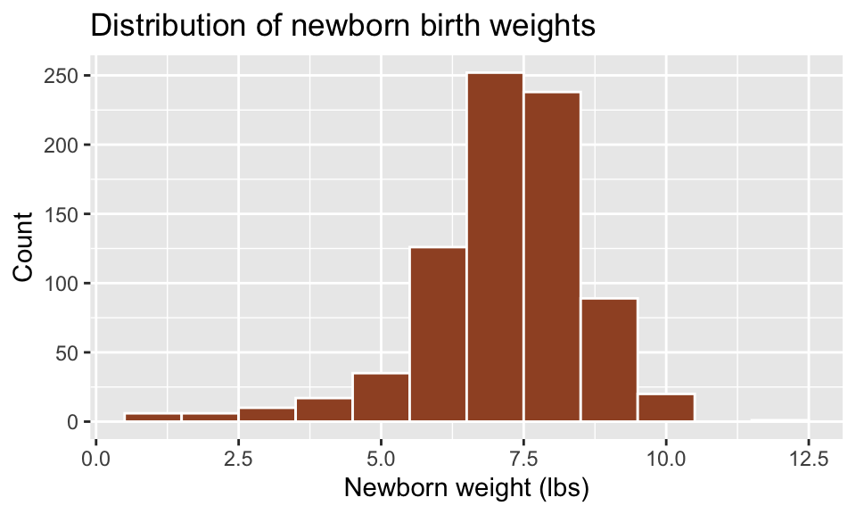

```r
ggplot(data = nc, aes(x =  weight)) +
  geom_histogram(binwidth = 1, color = "white", fill = "sienna") +
  labs(x = "Newborn weight (lbs)", y = "Count", title = "Distribution of newborn birth weights")
```

## Exercise 8

Make a histogram of newborn birth `weight` split by `gender` of the child. Set the binwidth to 0.5. Which gender appears to have a slightly larger average birth weight? (code and text to answer)

**Answer: Males have a slightly higher average birth weight**

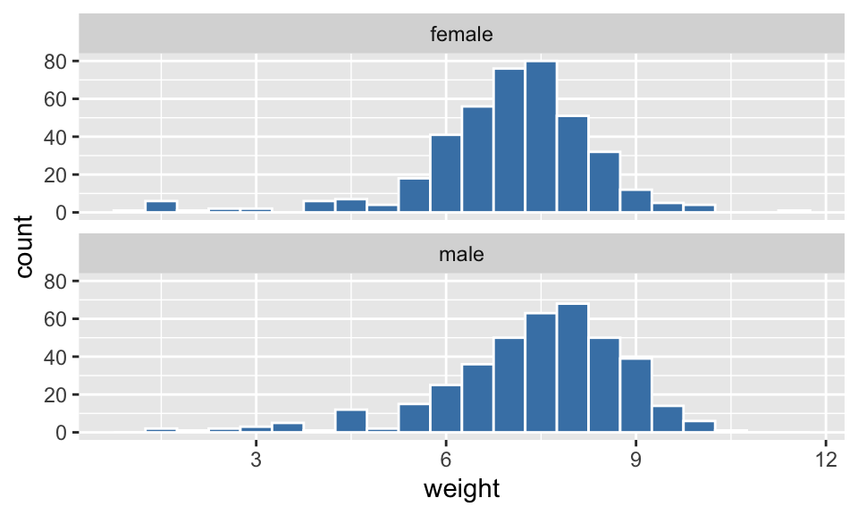

```r
ggplot(data = nc, aes(x = weight)) +
  geom_histogram(binwidth = 0.5, color = "white", fill = "steelblue") +
  facet_wrap(~ gender, ncol = 1)
```

## Exercise 9

Make a boxplot of the weight `gained` by moms, split by the maturity status of the mothers (`mature`). Include axis labels and a title on your plot. Is the **median** weight gain during pregnancy larger for younger or older moms? (text and code)

**Answer it is slighly greater for younger moms**

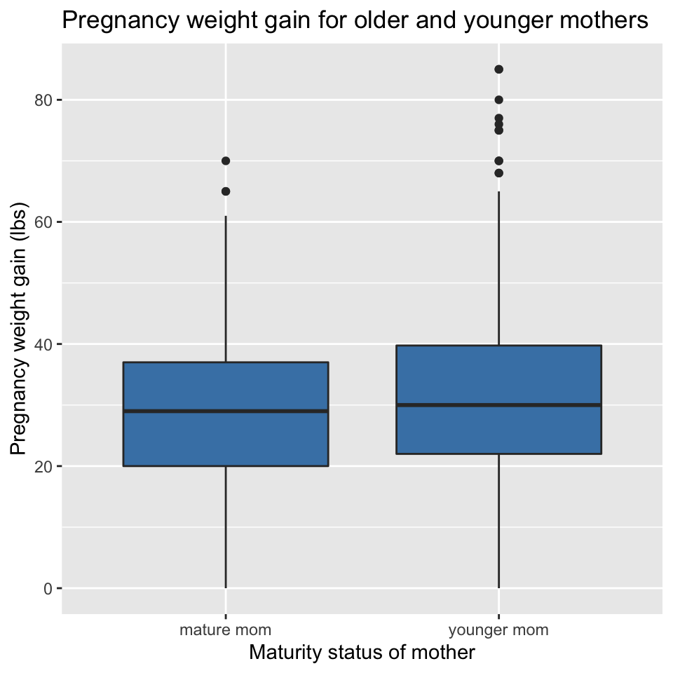

```r
ggplot(data = nc, aes(x = mature, y = gained)) +
  geom_boxplot(fill = "steelblue") +
  labs(x = "Maturity status of mother", y = "Pregnancy weight gain (lbs)",
       title = "Pregnancy weight gain for older and younger mothers")
```

## Exercise 10

Make a boxplot of pregnancy duration by smoking `habit`. Is the duration of pregnancy more **variable** for smokers or non-smokers? (i.e. which group has the greater spread for the variable `weeks`?). (code and text to answer)

**answer: based on the RANGE, pregnancy duration is more variable for nonsmokers…based on the IQR pregnancy duration is more variable for smokers**

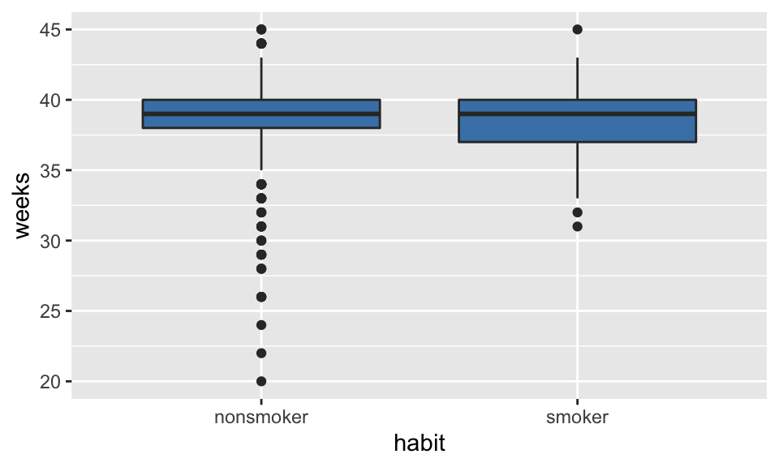

```r
ggplot(data = nc, aes(x = habit, y = weeks)) +
  geom_boxplot(fill = "steelblue")
```

# Independent Practice

## Exercise 11

Using a data visualization, visually assess: Is the variable for father’s age (`fage`) symmetrical, or does it have a skew?

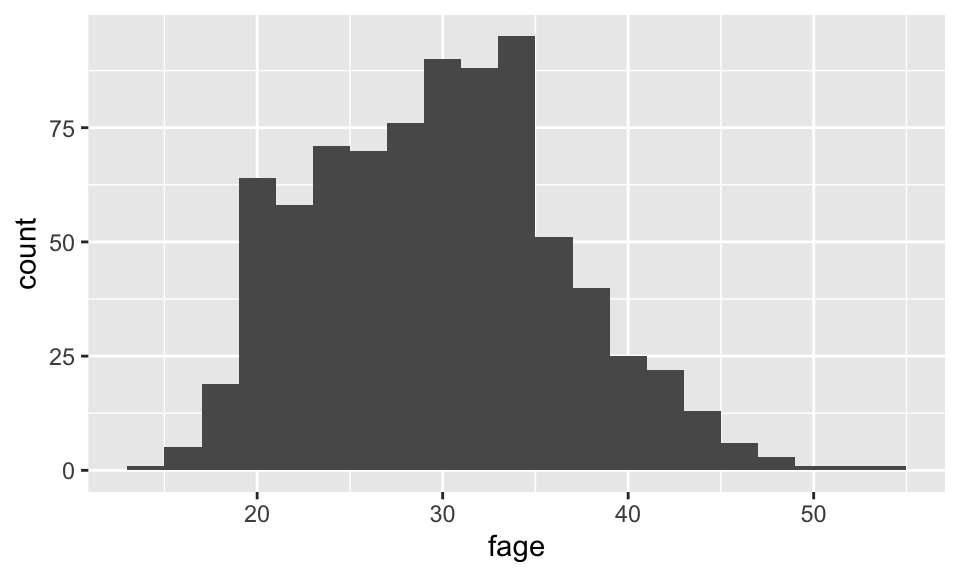

```r
ggplot(data = nc, aes(x = fage)) +
  geom_histogram(binwidth = 2)
```

**Answer: there is a right skew. Note to the grader…technically a boxplot could also be used to assess this…though we did not show the students how**

## Exercise 12

Using a data visualization, visually assess: (in this sample) is the median birth `weight` of babies greater for white or non-white mothers (variable called `whitemom`)?

**Answer: median weight of babies is greater for white mothers**

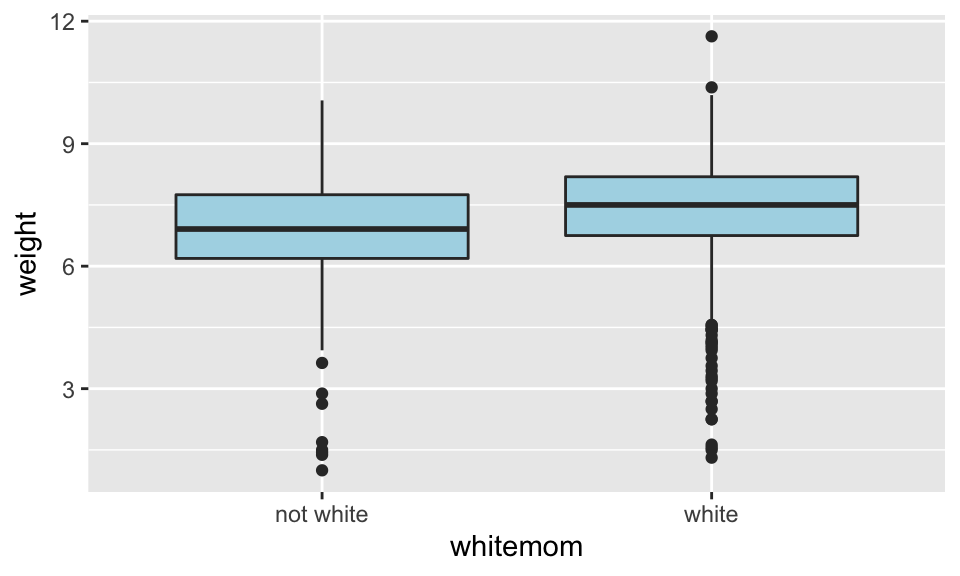

```r
ggplot(data = nc, aes(x = whitemom, y = weight)) +
  geom_boxplot(fill = "lightblue")
```

## Exercise 13

Using a data visualization, visually assess: (in this sample) as a mother’s age increases, does the duration of pregnancy appear to decrease?

*Answer: no…there does not appear to be much of a relationship**

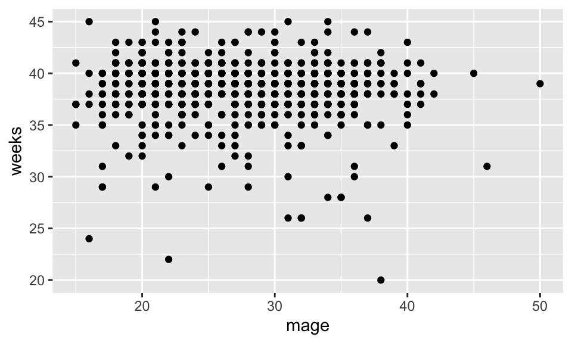

```r
ggplot(data = nc, aes(x = mage, y = weeks)) +
  geom_point()
```